# Deep Learning Ensembles for VIX Forecasting: A Multi-Horizon N-BEATS Approach

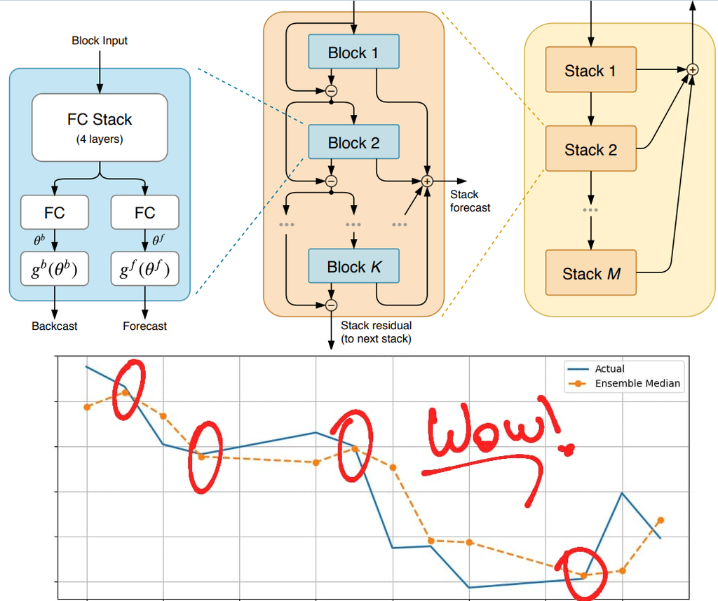

We forecast the **VIX** index using a multi-horizon **N-BEATS** deep-learning pipeline in a 9-model ensemble stack using **PyTorch**. Each model predicts the VIX Close value of the next day and we then aggregate different model forecasts in a **median** to power-up our ensemble stack.

We use **Dropout** layers for regularization, **ADAM** with L2 regularization as our optimizer, **Huber Loss** as our loss function and early-stopping to reduce training time. We train our model on an **NVIDIA GeForce RTX 4080** GPU by utilizing the **CUDA** framework.

Finally, we test our model against the actual future values and calculate the **Mean Absolute Percentage Error (MAPE)** to measure the performance of our forecasts. The result is a simple, fast, and accurate deep-learning forecaster for market volatility.

```python
# Import necessary libraries
import numpy as np
import pandas as pd
from matplotlib import pyplot as plt
import yfinance as yf
import torch
from torch import nn
import torchinfo
from datetime import date
```

We download the VIX data using **yfinance** and split it for 20 years of in-sample training and 1 year of out-of-sample testing periods.

```python
trainval_start_date = date(2004, 8, 9)
trainval_end_date = date(2024, 8, 9)
test_start_date = trainval_end_date
test_end_date = date(2025, 8, 9)
ticker = "^VIX"

data = yf.download(ticker, trainval_start_date, test_end_date)
data = data.droplevel(1, axis=1)
```

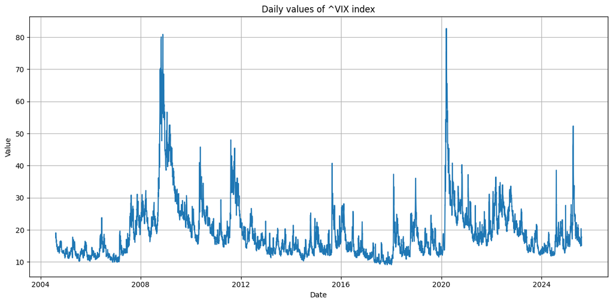

```python
fig, ax = plt.subplots(1, 1, figsize=(12, 6))

ax.plot(data["Close"])
ax.set_title(f"Daily values of {ticker} index")
ax.set_ylabel("Value")
ax.set_xlabel("Date")
ax.grid()

fig.tight_layout()
```

The **VIX**, or CBOE Volatility Index, is a widely followed indicator of the market's expectation of future volatility as implied by S&P 500 index options. The VIX is designed to quantify expected **stock market volatility** in the near term, serving as a forward-looking gauge based on options market activity. Its quoted value reflects the market’s consensus for the **annualized percentage change in the S&P 500** over the next 30 days, derived from options-pricing models and real-time options data. In essence, it is a volatility index calculated from S&P 500 options, with each option’s price embodying the market’s expectation of **30-day future volatility**.

We are going to use the **N-BEATS** architecture by *Boris N. Oreshkin, Dmitri Carpov, Nicolas Chapados, Yoshua Bengio*, which has proven immense success in prediction problems in univariate time series domain. N-BEATS is a powerful deep learning architecture for time series forecasting because it leverages a simple-to-understand but highly expressive fully connected network without reliance on time-series-specific feature engineering. Its block-based structure, where each block provides both a backcast and a forecast, allows iterative residual learning that improves the prediction increasingly in each iteration. The doubly residual stacking of the novel architecture can propagate gradients successfully and allows the model to decompose the input signal into significant components, such as trend and seasonality, without sacrificing performance. All this is achieved with flexibility, interpretability, and state-of-the-art accuracy on a broad variety of forecasting benchmarks, which makes N-BEATS a compelling choice for time series analysis.

(Reference: https://arxiv.org/abs/1905.10437 - *N-BEATS: Neural basis expansion analysis for interpretable time series forecasting, Boris N. Oreshkin, Dmitri Carpov, Nicolas Chapados, Yoshua Bengio*)

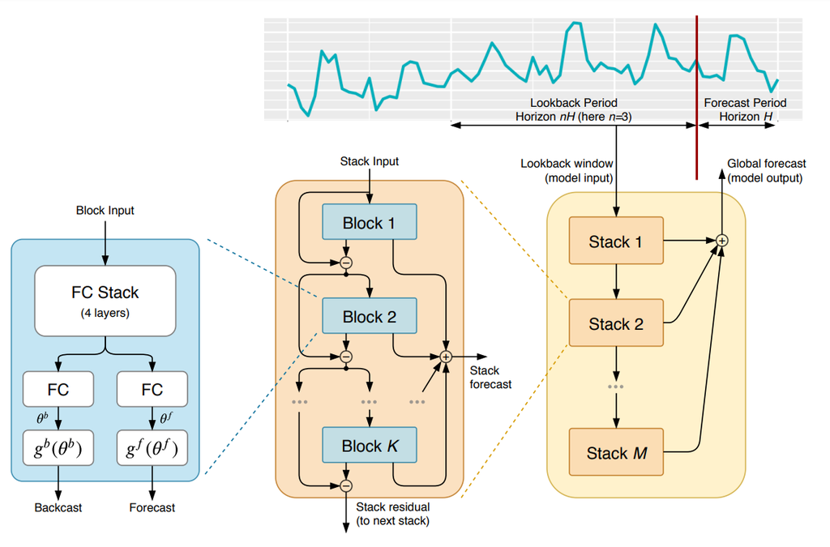

(Reference: https://arxiv.org/abs/1905.10437 - *N-BEATS: Neural basis expansion analysis for interpretable time series forecasting, Boris N. Oreshkin, Dmitri Carpov, Nicolas Chapados, Yoshua Bengio*)

We begin by designing the Block component of the N-BEATS architecture, the core unit responsible for transforming historical input data into both backcast (reconstructed past) and forecast (predicted future) outputs.

For simplicity, the intermediate layer sizes are chosen as multiples of $256$, a common convention in deep learning, while hyperparameter tuning is left out of scope for this demonstration.

To enhance the model’s ability to generalize and avoid overfitting, we introduce Dropout regularization after key fully connected layers. The block’s output is then split into two parallel linear transformations: one producing the backcast signal and the other generating the forecast for the defined horizon $H$.

```python
class NBEATSBlock(nn.Module):
    def __init__(self, H, n, dropout_prob=0.1):
        """
        Parameters:
        H (int): Forecast horizon (number of future time steps to predict)
        n (int): How many times the forecast horizon to look back
        """
        super().__init__()
        self.stem = nn.Sequential(  # input size: (batch_size, 1, H*n)
            nn.Linear(in_features=H*n, out_features=512), nn.ReLU(), nn.Dropout(dropout_prob),
            nn.Linear(in_features=512, out_features=1024), nn.ReLU(), nn.Dropout(dropout_prob),
            nn.Linear(in_features=1024, out_features=512), nn.ReLU(), nn.Dropout(dropout_prob),
            nn.Linear(in_features=512, out_features=256), nn.ReLU()
        )

        # In generic architecture, the backcast and forecast transformations are just linear layers
        self.backcast = nn.Linear(in_features=256, out_features=H*n)
        self.forecast = nn.Linear(in_features=256, out_features=H)

    def forward(self, x):
        x = self.stem(x)
        x_bc = self.backcast(x)
        x_fc = self.forecast(x)

        return x_bc, x_fc
```

The *torchinfo* library offers a quick and intuitive way to inspect the architecture of a PyTorch model, making it easier to understand the flow of data and the size of intermediate layers.

Here, we use torchinfo to visualize the structure of our first building block, NBEATSBlock. In our full ensemble setup, the lookback multiplier $n$ will vary across models $(2, 3, \dots, 10)$, but for illustration purposes, we select $n=5$. The forecast horizon $H$ is set to 1, meaning the block will predict one time step ahead using data from $n \cdot H = 5$ past time steps.

```python
H = 1  # Forecast horizon
n = 5  # Sample n value, look back n times the forecast horizon

model = NBEATSBlock(H, n)
model.to("cuda")
torchinfo.summary(model, input_size=(1, H*n))
```

```
==========================================================================================
Layer (type:depth-idx)                   Output Shape              Param #
==========================================================================================
NBEATSBlock                              [1, 5]                    --
├─Sequential: 1-1                        [1, 256]                  --
│    └─Linear: 2-1                       [1, 512]                  3,072
│    └─ReLU: 2-2                         [1, 512]                  --
│    └─Dropout: 2-3                      [1, 512]                  --
│    └─Linear: 2-4                       [1, 1024]                 525,312
│    └─ReLU: 2-5                         [1, 1024]                 --
│    └─Dropout: 2-6                      [1, 1024]                 --
│    └─Linear: 2-7                       [1, 512]                  524,800
│    └─ReLU: 2-8                         [1, 512]                  --
│    └─Dropout: 2-9                      [1, 512]                  --
│    └─Linear: 2-10                      [1, 256]                  131,328
│    └─ReLU: 2-11                        [1, 256]                  --
├─Linear: 1-2                            [1, 5]                    1,285
├─Linear: 1-3                            [1, 1]                    257
==========================================================================================
Total params: 1,186,054
Trainable params: 1,186,054
Non-trainable params: 0
Total mult-adds (Units.MEGABYTES): 1.19
==========================================================================================
Input size (MB): 0.00
Forward/backward pass size (MB): 0.02
Params size (MB): 4.74
Estimated Total Size (MB): 4.76
==========================================================================================
```

Next, we construct the Stack component of the N-BEATS architecture, which is essentially a sequence of **Block**s.

While PyTorch’s *nn.Sequential* is a convenient tool for chaining modules together in a purely feed-forward manner—where the output of one layer becomes the input to the next—it cannot handle our case directly. The reason is that each **NBEATSBlock** produces two outputs:

**Backcast:** the part of the input signal the block tries to reconstruct.

**Forecast:** the model’s prediction for the future horizon.

In our stack, the backcast must be subtracted from the current residual before passing it to the next block. This iterative residual update is at the heart of N-BEATS, but it requires custom control flow. Since *nn.Sequential* does not allow for such multi-output, state-updating logic, we instead use *nn.ModuleList*, which gives us full flexibility in the forward pass.

In the **NBEATSStack** implementation below, we:

1. Initialize $K=30$ blocks in a **ModuleList**.
2. Keep track of a running sum of forecasts across all blocks.
3. Iteratively update the residual by removing the block’s backcast.
4. Return the final residual and the aggregated forecast.

```python
class NBEATSStack(nn.Module):
    def __init__(self, K, H, n):
        """
        Parameters:
        K (int): Number of blocks in the stack
        H (int): Forecast horizon (number of future time steps to predict)
        n (int): How many times the forecast horizon to look back
        """
        super().__init__()
        self.blocks = nn.ModuleList([NBEATSBlock(H, n) for _ in range(K)])

    def forward(self, x):
        x_fc_sum = torch.zeros(x.size(0), H, dtype=x.dtype).to(x.device)
        residual = x  # start with the original input
        for block in self.blocks:
            x_bc, x_fc = block(residual)
            residual = residual - x_bc  # update residual using the block’s input
            x_fc_sum += x_fc
        return residual, x_fc_sum
```

```python
K = 30  # Number of blocks in the stack

model = NBEATSStack(K, H, n)
model.to("cuda")
torchinfo.summary(model, input_size=(1, H*n))
```

```
==========================================================================================
Layer (type:depth-idx)                   Output Shape              Param #
==========================================================================================
NBEATSStack                              [1, 5]                    --
├─ModuleList: 1-1                        --                        --
│    └─NBEATSBlock: 2-1                  [1, 5]                    --
│    │    └─Sequential: 3-1              [1, 256]                  1,184,512
│    │    └─Linear: 3-2                  [1, 5]                    1,285
│    │    └─Linear: 3-3                  [1, 1]                    257
│    └─NBEATSBlock: 2-2                  [1, 5]                    --
│    │    └─Sequential: 3-4              [1, 256]                  1,184,512
│    │    └─Linear: 3-5                  [1, 5]                    1,285
│    │    └─Linear: 3-6                  [1, 1]                    257
│    └─NBEATSBlock: 2-3                  [1, 5]                    --
│    │    └─Sequential: 3-7              [1, 256]                  1,184,512
│    │    └─Linear: 3-8                  [1, 5]                    1,285
│    │    └─Linear: 3-9                  [1, 1]                    257
│    └─NBEATSBlock: 2-4                  [1, 5]                    --
│    │    └─Sequential: 3-10             [1, 256]                  1,184,512
│    │    └─Linear: 3-11                 [1, 5]                    1,285
│    │    └─Linear: 3-12                 [1, 1]                    257
│    └─NBEATSBlock: 2-5                  [1, 5]                    --
│    │    └─Sequential: 3-13             [1, 256]                  1,184,512
│    │    └─Linear: 3-14                 [1, 5]                    1,285
│    │    └─Linear: 3-15                 [1, 1]                    257
│    └─NBEATSBlock: 2-6                  [1, 5]                    --
│    │    └─Sequential: 3-16             [1, 256]                  1,184,512
│    │    └─Linear: 3-17                 [1, 5]                    1,285
│    │    └─Linear: 3-18                 [1, 1]                    257
│    └─NBEATSBlock: 2-7                  [1, 5]                    --
│    │    └─Sequential: 3-19             [1, 256]                  1,184,512
│    │    └─Linear: 3-20                 [1, 5]                    1,285
│    │    └─Linear: 3-21                 [1, 1]                    257
│    └─NBEATSBlock: 2-8                  [1, 5]                    --
│    │    └─Sequential: 3-22             [1, 256]                  1,184,512
│    │    └─Linear: 3-23                 [1, 5]                    1,285
│    │    └─Linear: 3-24                 [1, 1]                    257
│    └─NBEATSBlock: 2-9                  [1, 5]                    --
│    │    └─Sequential: 3-25             [1, 256]                  1,184,512
│    │    └─Linear: 3-26                 [1, 5]                    1,285
```

[output cut: 81 more lines]

```
│    └─NBEATSBlock: 2-30                 [1, 5]                    --
│    │    └─Sequential: 3-88             [1, 256]                  1,184,512
│    │    └─Linear: 3-89                 [1, 5]                    1,285
│    │    └─Linear: 3-90                 [1, 1]                    257
==========================================================================================
Total params: 35,581,620
Trainable params: 35,581,620
Non-trainable params: 0
Total mult-adds (Units.MEGABYTES): 35.58
==========================================================================================
Input size (MB): 0.00
Forward/backward pass size (MB): 0.55
Params size (MB): 142.33
Estimated Total Size (MB): 142.88
==========================================================================================
```

Finally, we assemble the full N-BEATS architecture by stacking multiple **NBEATSStack** modules on top of each other. This hierarchical design is what allows the network to progressively refine its predictions. Each stack operates on the residual signal left by the previous stack, just as each block operates on the residual from the previous block. Moreover, forecasts from all stacks are aggregated to produce the final prediction.

The top-level NBEATS class therefore orchestrates the flow of information across the entire model:

1. **Initialization:** We create $M=3$ stacks, each consisting of $K=30$ residual blocks.
2. **Forward Pass:** The input passes through each stack **sequentially**. After each stack, we update the residual by removing the backcast, then add the stack’s forecast to a running total.
3. **Output:** The aggregated forecast from all stacks is returned as the model’s prediction.

```python
class NBEATS(nn.Module):
    def __init__(self, M, K, H, n):
        """
        Parameters:
        M (int): Number of stacks in the network
        K (int): Number of blocks in the stack
        H (int): Forecast horizon (number of future time steps to predict)
        n (int): How many times the forecast horizon to look back
        """
        super().__init__()
        self.H = H
        self.stacks = nn.ModuleList([NBEATSStack(K, H, n) for _ in range(M)])

    def forward(self, x):
        # Initialize forecast accumulator
        forecast_total = torch.zeros(x.size(0), self.H,
                                  device=x.device, dtype=x.dtype)
        residual = x

        for stack in self.stacks:
            # Process through stack
            residual, stack_forecast = stack(residual)
            # Aggregate forecasts
            forecast_total += stack_forecast

        return forecast_total
```

Below, we instantiate the model with three stacks $(M = 3)$, move it to **GPU**, and use *torchinfo* to summarize its architecture. This provides a clear picture of how our blocks and stacks scale up into the final deep learning model.

```python
M = 3 # Number of stacks in the network

model = NBEATS(M, K, H, n)
model.to("cuda")
torchinfo.summary(model, input_size=(1, H*n))
```

```
===============================================================================================
Layer (type:depth-idx)                        Output Shape              Param #
===============================================================================================
NBEATS                                        [1, 1]                    --
├─ModuleList: 1-1                             --                        --
│    └─NBEATSStack: 2-1                       [1, 5]                    --
│    │    └─ModuleList: 3-1                   --                        35,581,620
│    └─NBEATSStack: 2-2                       [1, 5]                    --
│    │    └─ModuleList: 3-2                   --                        35,581,620
│    └─NBEATSStack: 2-3                       [1, 5]                    --
│    │    └─ModuleList: 3-3                   --                        35,581,620
===============================================================================================
Total params: 106,744,860
Trainable params: 106,744,860
Non-trainable params: 0
Total mult-adds (Units.MEGABYTES): 106.74
===============================================================================================
Input size (MB): 0.00
Forward/backward pass size (MB): 1.66
Params size (MB): 426.98
Estimated Total Size (MB): 428.64
===============================================================================================
```

With the N-BEATS architecture fully defined, using $M=3$ **stacks** and $K=30$ **blocks** in each stack, we now move to the training stage. The network contains more than *100 million* trainable parameters, which makes it highly data-hungry. To ensure the model is exposed to a wide variety of market regimes, we train it on a long historical record of **VIX** closing values. This period spans from 2004 to 2024 and includes calm markets, sharp volatility spikes, and prolonged high-volatility episodes, allowing the model to learn from a broad spectrum of conditions.

For the evaluation phase, the final year of data is kept completely out of the training process and serves as a pure out-of-sample test set. This approach provides an unbiased assessment of the model’s forecasting ability in real-world conditions. The data is retrieved directly through the yfinance API, giving us clean and consistent time series for both the training and testing periods.

```python
trainval_data = yf.download(ticker, trainval_start_date, trainval_end_date).droplevel(1, axis=1)["Close"]
test_data = yf.download(ticker, test_start_date, test_end_date).droplevel(1, axis=1)["Close"]

print()
print("-"*50)
print()
print("Train/Validation Data")
print(trainval_data.head(5))
print()
print("-"*50)
print()
print("Test Data")
print(test_data.head(5))
print()
```

```
--------------------------------------------------

Train/Validation Data
Date
2004-08-09    18.889999
2004-08-10    17.469999
2004-08-11    18.040001
2004-08-12    19.080000
2004-08-13    17.980000
Name: Close, dtype: float64

--------------------------------------------------

Test Data
Date
2024-08-09    20.370001
2024-08-12    20.709999
2024-08-13    18.120001
2024-08-14    16.190001
2024-08-15    15.230000
Name: Close, dtype: float64
```

Because we have built up the final **NBEATS** class, we can move on to create our ensemble pack. We are going to build $9$ models with different lookback periods $n=2, 3, \cdots, 10$. Each configuration results in a unique input length, calculated as $H \times n$ where $H$ is the forecast horizon (in our case $H=1$). These models are then stored for later use, ensuring that we can efficiently train, evaluate, and deploy them without repeatedly reconstructing the architecture.

```python
# Check for GPU
device = torch.device("cuda" if torch.cuda.is_available() else "cpu")
print("Using device:", device)

# Different history multipliers for ensemble
n_array = np.arange(2, 11)
history_lengths = H*n_array
print("Model count:", len(n_array))
print("History lengths:", history_lengths)
print("Forecast lengths:", H*np.ones(history_lengths.shape[0]))
print()

# Initialize ensemble models
models_array = [NBEATS(M, K, H, n).to(device) for n in n_array]
model_names = [f"model_{history_length}" for history_length in history_lengths]
models_dict = {model_name:model for model_name, model in zip(model_names, models_array)}
print("    First model for example:")
print(list(models_dict.items())[0])
```

```
Using device: cuda
Model count: 9
History lengths: [ 2  3  4  5  6  7  8  9 10]
Forecast lengths: [1. 1. 1. 1. 1. 1. 1. 1. 1.]

    First model for example:
('model_2', NBEATS(
  (stacks): ModuleList(
    (0-2): 3 x NBEATSStack(
      (blocks): ModuleList(
        (0-29): 30 x NBEATSBlock(
          (stem): Sequential(
            (0): Linear(in_features=2, out_features=512, bias=True)
            (1): ReLU()
            (2): Dropout(p=0.1, inplace=False)
            (3): Linear(in_features=512, out_features=1024, bias=True)
            (4): ReLU()
            (5): Dropout(p=0.1, inplace=False)
            (6): Linear(in_features=1024, out_features=512, bias=True)
            (7): ReLU()
            (8): Dropout(p=0.1, inplace=False)
            (9): Linear(in_features=512, out_features=256, bias=True)
            (10): ReLU()
          )
          (backcast): Linear(in_features=256, out_features=2, bias=True)
          (forecast): Linear(in_features=256, out_features=1, bias=True)
        )
      )
    )
  )
))
```

Then, we featurize our dataset with labels: for every day, previous $H \times n$ trading days will be used as features, and the next $H$ days will be used as labels. Note that in this study, we have set $H=1$, so our model is going to forecast only the next day.

```python
def featurize_series_NBEATS(series, H, n):
    """
    Parameters:
    series (pd.Series): Time series to convert to PyTorch tensor
    H (int): Forecast horizon (number of future time steps to predict)
    n (int): How many times the forecast horizon to look back
    """
    series = series.values.astype(np.float32)

    # Create the feature tensor X by rolling the series n times
    num_rows = len(series) - H*n - H + 1
    X = np.zeros((num_rows, H*n))
    Y = np.zeros((num_rows, H))
    for i in range(num_rows):
        X[i, :] = series[i : i + H*n]
        Y[i, :] = series[i + H*n : i + H*n + H]

    X = torch.tensor(X, dtype=torch.float32)
    Y = torch.tensor(Y, dtype=torch.float32)

    return X, Y
```

To make our model more robust and capable of generalizing to unseen data, we split the featurized dataset into training and validation sets. The training set is used to fit the model, while the validation set provides an unbiased check on its performance during each epoch.

We use a validation ratio of $0.2$, meaning $20 \% $ of the most recent data is set aside for validation, and the remaining $80 \%$ is used for training. This approach lets us track both training and validation losses side by side, helping us choose the best-performing model weights and reduce the risk of overfitting. Since we keep the data in chronological order, we also preserve the natural flow of time, which is essential in forecasting tasks.

```python
def train_val_split(X, Y, val_size=0.2):
    """
    Parameters:
    X (torch.Tensor): Input feature tensor
    Y (torch.Tensor): Target tensor
    val_size (float): Proportion of the data to use for validation
    """
    num_train = int((1-val_size) * len(X))
    X_train, Y_train = X[:num_train], Y[:num_train]
    X_val, Y_val = X[num_train:], Y[num_train:]

    return X_train, Y_train, X_val, Y_val
```

Then we initialize PyTorch *TensorDataset* and *DataLoader* objects to prepare our dataset for training, choosing a **batch size** of $1024$, also the chosen value in the paper.

```python
from torch.utils.data import TensorDataset, DataLoader

batch_size = 1024
loaders_dict = {}
for idx, (model_name, model) in enumerate(models_dict.items()):
    n = n_array[idx]
    X, Y = featurize_series_NBEATS(trainval_data, H, n)
    X_train, Y_train, X_val, Y_val = train_val_split(X, Y, val_size=0.2)
    loaders_dict[model_name] = {
        "train_loader":DataLoader(TensorDataset(X_train, Y_train), batch_size=batch_size, shuffle=True),
        "val_loader":DataLoader(TensorDataset(X_val, Y_val), batch_size=batch_size, shuffle=False)
    }
```

We choose **MAPE** for our test performance metric but will not be using it as our main loss function. But you can always uncomment the *MAPELoss()* line in the training loop to try a different loss function for training.

```python
def calc_mape(y_true, y_pred, eps=1e-6):
    mape = torch.mean(torch.abs((y_true - y_pred) / (y_true + eps))) * 100
    return mape

class MAPELoss(nn.Module):
    def __init__(self, eps=1e-8):
        super(MAPELoss, self).__init__()
        self.eps = eps  # to avoid division by zero

    def forward(self, y_pred, y_true):
        # y_pred: predicted values
        # y_true: actual values
        loss = torch.mean(torch.abs((y_true - y_pred) / (y_true + self.eps))) * 100
        return loss
```

With the ensemble initialized, we proceed to the training phase, where each of the $9$ N-BEATS models is trained independently. Throughout training, we track both **training** and **validation** losses at every epoch to monitor learning progress and detect **overfitting**.

Given that each model contains more than *100 million* trainable parameters, saving intermediate results is essential. We implement **early stopping** to prevent wasted computation and to improve **generalization**: if the validation loss does not improve for $20$ consecutive epochs *(patience parameter)*, training halts and the best-performing weights are preserved.

In addition, a learning rate **scheduler** is employed to gradually reduce the learning rate when progress stalls, specifically halving it after three epochs without improvement in validation loss. This helps the optimizer converge more reliably to a well-performing solution.

The final outcome of this process is two saved versions for each model: the **best** checkpoint according to validation loss and the **final** state at the end of training, ensuring flexibility for later evaluation and ensemble integration.

```python
def train_NBEATS(train_loader, val_loader, model, device, model_name):
    num_epochs = 100
    train_losses = []
    val_losses = []
    best_val_loss = float('inf')
    patience = 20
    epochs_without_improve = 0

    loss_func = torch.nn.SmoothL1Loss(beta=0.5)  # Huber
    # loss_func = MAPELoss()
    optimizer = torch.optim.Adam(model.parameters(), lr=1e-3, weight_decay=1e-4)
    scheduler = torch.optim.lr_scheduler.ReduceLROnPlateau(optimizer, mode='min', factor=0.5, patience=3)

    save_path_best = f"best_nbeats_weights_{model_name}.pth"
    save_path_final = f"nbeats_model_weights_final_{model_name}.pth"

    for epoch in range(num_epochs):
        # Training loop
        model.train()
        running_train_loss = 0.0
        for inputs, targets in train_loader:
            inputs = inputs.to(device) # shape: (batch_size, H*n)
            targets = targets.to(device) # shape: (batch_size, H)

            optimizer.zero_grad()
            forecasts = model(inputs) # forecast shape: (batch_size, H)
            loss = loss_func(forecasts, targets)
            loss.backward()
            optimizer.step()
            running_train_loss += loss.item() * inputs.size(0)

        epoch_train_loss = running_train_loss / len(train_loader.dataset)
        train_losses.append(epoch_train_loss)

        # Validation loop
        model.eval()
        running_val_loss = 0.0
        with torch.no_grad():
            for inputs, targets in val_loader:
                inputs = inputs.to(device)
                targets = targets.to(device)
                forecasts = model(inputs)
                loss = loss_func(forecasts, targets)
                running_val_loss += loss.item() * inputs.size(0)
        epoch_val_loss = running_val_loss / len(val_loader.dataset)
        val_losses.append(epoch_val_loss)
        scheduler.step(epoch_val_loss)

        print(f"Epoch {epoch+1}/{num_epochs} - Train Loss: {epoch_train_loss:.4f} - Val Loss: {epoch_val_loss:.4f}")

        # Early stopping: check if validation loss improved
        if epoch_val_loss < best_val_loss:
            best_val_loss = epoch_val_loss
            epochs_without_improve = 0
            # Optionally save the best model here
            torch.save(model.state_dict(), save_path_best)
            print(f"    Best model weights so far saved to {save_path_best}")
        else:
            epochs_without_improve += 1
            if epochs_without_improve >= patience:
                print(f"Early stopping triggered after {epoch+1} epochs.")
                break

    # Save the final model weights
    torch.save(model.state_dict(), save_path_final)
    print(f"    Final model weights saved to {save_path_final}")

    return train_losses, val_losses

train_losses_dict = {}
val_losses_dict = {}
for model_name, model in models_dict.items():
    train_loader = loaders_dict[model_name]["train_loader"]
    val_loader = loaders_dict[model_name]["val_loader"]
    train_losses, val_losses = train_NBEATS(train_loader, val_loader, model, device, model_name)
    train_losses_dict[model_name] = train_losses
    val_losses_dict[model_name] = val_losses
```

```
    Best model weights so far saved to best_nbeats_weights_model_2.pth
    Best model weights so far saved to best_nbeats_weights_model_2.pth
    Best model weights so far saved to best_nbeats_weights_model_2.pth
    Best model weights so far saved to best_nbeats_weights_model_2.pth
    Best model weights so far saved to best_nbeats_weights_model_2.pth
    Best model weights so far saved to best_nbeats_weights_model_2.pth
    Best model weights so far saved to best_nbeats_weights_model_2.pth
    Best model weights so far saved to best_nbeats_weights_model_2.pth
    Best model weights so far saved to best_nbeats_weights_model_2.pth
    Best model weights so far saved to best_nbeats_weights_model_2.pth
    Best model weights so far saved to best_nbeats_weights_model_2.pth
Early stopping triggered after 39 epochs.
    Final model weights saved to nbeats_model_weights_final_model_2.pth
    Best model weights so far saved to best_nbeats_weights_model_3.pth
    Best model weights so far saved to best_nbeats_weights_model_3.pth
    Best model weights so far saved to best_nbeats_weights_model_3.pth
    Best model weights so far saved to best_nbeats_weights_model_3.pth
    Best model weights so far saved to best_nbeats_weights_model_3.pth
    Best model weights so far saved to best_nbeats_weights_model_3.pth
Early stopping triggered after 32 epochs.
    Final model weights saved to nbeats_model_weights_final_model_3.pth
    Best model weights so far saved to best_nbeats_weights_model_4.pth
    Best model weights so far saved to best_nbeats_weights_model_4.pth
    Best model weights so far saved to best_nbeats_weights_model_4.pth
    Best model weights so far saved to best_nbeats_weights_model_4.pth
    Best model weights so far saved to best_nbeats_weights_model_4.pth
    Best model weights so far saved to best_nbeats_weights_model_4.pth
Early stopping triggered after 36 epochs.
    Final model weights saved to nbeats_model_weights_final_model_4.pth
    Best model weights so far saved to best_nbeats_weights_model_5.pth
    Best model weights so far saved to best_nbeats_weights_model_5.pth
    Best model weights so far saved to best_nbeats_weights_model_5.pth
    Best model weights so far saved to best_nbeats_weights_model_5.pth
    Best model weights so far saved to best_nbeats_weights_model_5.pth
    Best model weights so far saved to best_nbeats_weights_model_5.pth
    Best model weights so far saved to best_nbeats_weights_model_5.pth
    Best model weights so far saved to best_nbeats_weights_model_5.pth
    Best model weights so far saved to best_nbeats_weights_model_5.pth
    Best model weights so far saved to best_nbeats_weights_model_5.pth
    Best model weights so far saved to best_nbeats_weights_model_5.pth
```

[output cut: 67 more lines]

```
Early stopping triggered after 57 epochs.
    Final model weights saved to nbeats_model_weights_final_model_9.pth
    Best model weights so far saved to best_nbeats_weights_model_10.pth
    Best model weights so far saved to best_nbeats_weights_model_10.pth
    Best model weights so far saved to best_nbeats_weights_model_10.pth
    Best model weights so far saved to best_nbeats_weights_model_10.pth
    Best model weights so far saved to best_nbeats_weights_model_10.pth
    Best model weights so far saved to best_nbeats_weights_model_10.pth
    Best model weights so far saved to best_nbeats_weights_model_10.pth
    Best model weights so far saved to best_nbeats_weights_model_10.pth
    Best model weights so far saved to best_nbeats_weights_model_10.pth
    Best model weights so far saved to best_nbeats_weights_model_10.pth
    Best model weights so far saved to best_nbeats_weights_model_10.pth
Early stopping triggered after 42 epochs.
    Final model weights saved to nbeats_model_weights_final_model_10.pth
```

[figure not shown]

```python
# Plot the training and validation loss curves
num_rows = len(models_dict.items())
fig, axs = plt.subplots(num_rows, 2, figsize=(12, 2*num_rows), sharex=True)
for idx, (model_name, model) in enumerate(models_dict.items()):
    axs[idx, 0].plot(train_losses, marker='o', label="Training Loss")
    axs[idx, 0].set_xlabel("Epoch")
    axs[idx, 0].set_ylabel("Loss")
    axs[idx, 0].set_title(f"{model_name} Training Loss Curve")
    axs[idx, 0].legend()
    axs[idx, 0].grid()

    axs[idx, 1].plot(val_losses, marker='x', color='orange', label="Validation Loss")
    axs[idx, 1].set_xlabel("Epoch")
    axs[idx, 1].set_ylabel("Loss")
    axs[idx, 1].set_title(f"{model_name} Validation Loss Curve")
    axs[idx, 1].legend()
    axs[idx, 1].grid()
fig.tight_layout()
```

With the models set to evaluation mode, we generated **forecasts** for the entire test period and compared them against the **actual** observed values. Performance was measured using the **Mean Absolute Percentage Error (MAPE)**, which provided a clear, scale-independent metric for accuracy. The results showed strong consistency across the ensemble: **MAPE** values clustered between roughly $6.3 \%$ and $7.2 \%$ for most models, with only one outlier above $10 \%$.

The forecasts from each model were then aligned with the actual time series in a single *pd.DataFrame*, which also included a rolling **median** forecast across all models. This median served as the ensemble’s aggregate prediction, reducing the influence of any single model’s potential over or underestimation on a given day. The final DataFrame structure allowed for direct comparison between actual market values, individual model predictions, and the ensemble’s median output.

```python
def build_rolling_from_series(preds, test_series, L_back):
    fc = preds.detach().cpu().numpy() if torch.is_tensor(preds) else np.asarray(preds)
    N, H = fc.shape
    idx = test_series.index
    verif_index = pd.DatetimeIndex(idx[L_back : L_back + (N + H - 1)])

    T = len(verif_index)
    forecast_latest = np.full(T, np.nan); latest_origin = -np.ones(T, int)
    chosen_h = np.full(T, np.nan)
    actual = test_series.loc[verif_index].to_numpy(dtype=float)

    for i in range(N):
        for h in range(H):
            t = i + h
            if t >= T:
                break
            if i >= latest_origin[t]:
                forecast_latest[t] = fc[i, h]
                latest_origin[t] = i
                chosen_h[t] = h + 1

    df = pd.DataFrame({"Actual": actual, "Forecast_latest": forecast_latest,
                       "Chosen_origin_i": latest_origin, "Chosen_horizon": chosen_h}, index=verif_index)
    return df

# Check device
device = torch.device("cuda" if torch.cuda.is_available() else "cpu")
print("Using device:", device)

test_series = test_data
df_roll_array = []
idx = test_series.index
forecast_df = pd.DataFrame(index=idx)
forecast_df.loc[:, "Actual"] = test_series

file_prefix = "nbeats_model_weights_final_"
for model_name, model in models_dict.items():
    # Initialize the model architecture and load best weights
    n = int(model_name.split("_")[-1]) // H
    model = NBEATS(M, K, H, n).to(device)
    model.load_state_dict(torch.load(f"{file_prefix}{model_name}.pth", map_location=device))
    model.eval()
    print(f"Loaded final model weights from {file_prefix}{model_name}.pth")

    # Featurize the test series using the same H and n as training
    X_test, Y_test = featurize_series_NBEATS(test_series, H, n)

    # Move test data to device
    X_test = X_test.to(device)
    Y_test = Y_test.to(device)

    with torch.no_grad():
        preds = model(X_test)

    ytrue = Y_test

    # Compute test MAPE score
    test_loss = calc_mape(preds, ytrue).item()
    print(f"{model_name} Test MAPE Loss: {test_loss:.4f} %")

    L_back = X_test.shape[1]
    df_roll = build_rolling_from_series(preds, test_series, L_back)
    forecast_df[model_name] = df_roll["Forecast_latest"]
forecast_df = forecast_df.dropna()
forecast_df["Median"] = forecast_df.median(axis=1)
forecast_df.head()
```

```
Using device: cuda
Loaded final model weights from nbeats_model_weights_final_model_2.pth
model_2 Test MAPE Loss: 7.2093 %
Loaded final model weights from nbeats_model_weights_final_model_3.pth
model_3 Test MAPE Loss: 7.1438 %
Loaded final model weights from nbeats_model_weights_final_model_4.pth
model_4 Test MAPE Loss: 10.0404 %
Loaded final model weights from nbeats_model_weights_final_model_5.pth
model_5 Test MAPE Loss: 6.6462 %
Loaded final model weights from nbeats_model_weights_final_model_6.pth
model_6 Test MAPE Loss: 6.3566 %
Loaded final model weights from nbeats_model_weights_final_model_7.pth
model_7 Test MAPE Loss: 6.3672 %
Loaded final model weights from nbeats_model_weights_final_model_8.pth
model_8 Test MAPE Loss: 6.4132 %
Loaded final model weights from nbeats_model_weights_final_model_9.pth
model_9 Test MAPE Loss: 6.4254 %
Loaded final model weights from nbeats_model_weights_final_model_10.pth
model_10 Test MAPE Loss: 6.5289 %
```

| Date | Actual | model_2 | model_3 | model_4 | model_5 | model_6 | model_7 | model_8 | model_9 | model_10 | Median |
| --- | --- | --- | --- | --- | --- | --- | --- | --- | --- | --- | --- |
| 2024-08-23 | 15.860000 | 16.450027 | 16.564945 | 15.585254 | 17.056746 | 17.307541 | 17.219681 | 17.522432 | 17.534481 | 17.316895 | 17.138213 |
| 2024-08-26 | 16.150000 | 16.027815 | 15.779881 | 15.211071 | 15.505700 | 15.735908 | 15.903193 | 16.122618 | 16.054993 | 15.796439 | 15.849816 |
| 2024-08-27 | 15.430000 | 15.514400 | 16.086626 | 15.306471 | 16.203259 | 16.005789 | 16.016212 | 16.062977 | 16.103230 | 15.955544 | 16.011001 |
| 2024-08-28 | 17.110001 | 15.233335 | 15.261698 | 14.702263 | 15.184162 | 15.381049 | 15.269513 | 15.451548 | 15.508391 | 15.155402 | 15.265605 |
| 2024-08-29 | 15.650000 | 15.895971 | 16.278345 | 15.399045 | 16.761518 | 16.802816 | 16.837919 | 16.909336 | 16.877373 | 16.900864 | 16.782167 |

To get a better understanding, we plot our 1-day forecasts against actual values in the test period: from **August 2024** to **August 2025**.

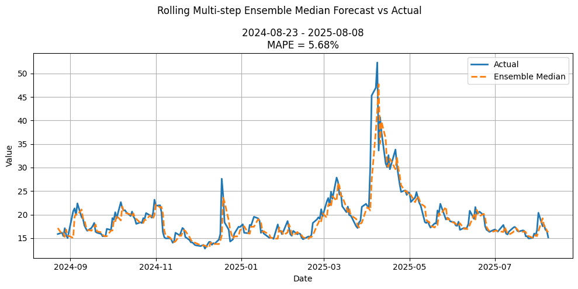

```python
def plot_forecast_vs_actual(forecast_df, forecast_start_date=None, forecast_end_date=None, marker=""):
    if forecast_start_date is None:
        forecast_start_date = forecast_df.index[0]
    if forecast_end_date is None:
        forecast_end_date = forecast_df.index[-1]

    mape = calc_mape(torch.asarray(forecast_df.loc[forecast_start_date:forecast_end_date, "Actual"]), torch.asarray(forecast_df.loc[forecast_start_date:forecast_end_date, "Median"]))
    mape = np.round(mape, 2)

    plt.figure(figsize=(10, 5))
    plt.plot(forecast_df.loc[forecast_start_date:forecast_end_date, :].index, forecast_df.loc[forecast_start_date:forecast_end_date, "Actual"], label="Actual", linewidth=2)
    plt.plot(forecast_df.loc[forecast_start_date:forecast_end_date, :].index, forecast_df.loc[forecast_start_date:forecast_end_date, "Median"], label="Ensemble Median", linewidth=2, linestyle="--", marker=marker)

    plt.suptitle(f"Rolling Multi-step Ensemble Median Forecast vs Actual")
    plt.title(f"{forecast_start_date.date()} - {forecast_end_date.date()}\nMAPE = {mape}%")
    plt.xlabel("Date")
    plt.ylabel("Value")
    plt.legend()
    plt.grid(True)
    plt.tight_layout()
    plt.show()

plot_forecast_vs_actual(forecast_df)
```

The plot shows tight tracking during quiet periods and credible responses around volatility spikes, which is reflected in the overall **MAPE** reported in the subtitle, which is an impressive $5.68 \%$. This visualization makes it easy to see where the ensemble anticipates turning points, how quickly it adapts after shocks, and where residual bias remains.

In the low-volatility period of mid-to-late July 2025, the ensemble network delivered highly accurate point forecasts, achieving a 15-day MAPE of only $1.97 \%$. The forecasts closely matched actual values point-wise, capturing subtle downward drifts and minor rebounds with minimal deviation which is indicative of strong short-horizon precision even under stable market dynamics.

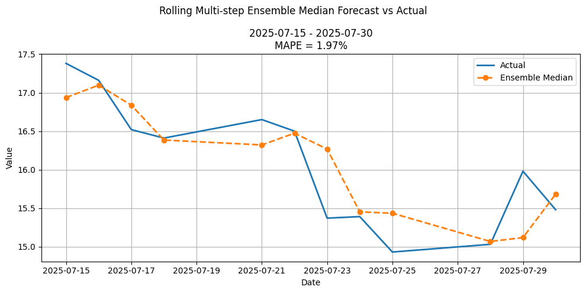

```python
forecast_start_date = pd.Timestamp("2025-07-15")
forecast_end_date = pd.Timestamp("2025-07-30")

plot_forecast_vs_actual(forecast_df, forecast_start_date, forecast_end_date, marker="o")
```

## Conclusion:

This work proposes a novel high-capacity, ensemble N-BEATS architecture to predict the VIX index, trained over two decades of past data and tested on a truly out-of-sample one-year test set. Through the combination of nine models with different lookback horizons within a median ensemble, the method is able to effectively incorporate both short-term volatility dynamics as well as longer-term structural trends. The results have good predictive power with a **Mean Absolute Percentage Error (MAPE)** of $5.68 \%$ for the test horizon, with much smaller errors $(\sim 2 \%)$ for low-volatility regimes. The findings indicate that the proposed ensemble method not only generalizes well across different volatility regimes but also delivers stable and strong performance without the need for advanced feature engineering. Thanks to its scalability, interpretability, and efficiency, the model holds excellent prospects for production deployment in real-world volatility forecasting and risk management systems.

### References:

- https://arxiv.org/abs/1905.10437 - *N-BEATS: Neural basis expansion analysis for interpretable time series forecasting, Boris N. Oreshkin, Dmitri Carpov, Nicolas Chapados, Yoshua Bengio*